# Ford GoBike tripdata analysis

## Preliminary Wrangling

> the Ford GoBike dataset which contains a wide range of trip data variables, which I think can be helpful interesting analyses once it it's wrangled in the appropriate way

```python
# import all packages and set plots to be embedded inline
import numpy as np
import pandas as pd
import matplotlib.pyplot as plt
import seaborn as sb

%matplotlib inline
```

> Load in your dataset and describe its properties through the questions below. Try and motivate your exploration goals through this section.

```python
df = pd.read_csv('201902-fordgobike-tripdata.csv')
```

```python
df.head()
```

|  | duration_sec | start_time | end_time | start_station_id | start_station_name | start_station_latitude | start_station_longitude | end_station_id | end_station_name | end_station_latitude | end_station_longitude | bike_id | user_type | member_birth_year | member_gender | bike_share_for_all_trip |
| --- | --- | --- | --- | --- | --- | --- | --- | --- | --- | --- | --- | --- | --- | --- | --- | --- |
| 0 | 52185 | 2019-02-28 17:32:10.1450 | 2019-03-01 08:01:55.9750 | 21.0 | Montgomery St BART Station (Market St at 2nd St) | 37.789625 | -122.400811 | 13.0 | Commercial St at Montgomery St | 37.794231 | -122.402923 | 4902 | Customer | 1984.0 | Male | No |
| 1 | 42521 | 2019-02-28 18:53:21.7890 | 2019-03-01 06:42:03.0560 | 23.0 | The Embarcadero at Steuart St | 37.791464 | -122.391034 | 81.0 | Berry St at 4th St | 37.775880 | -122.393170 | 2535 | Customer | NaN | NaN | No |
| 2 | 61854 | 2019-02-28 12:13:13.2180 | 2019-03-01 05:24:08.1460 | 86.0 | Market St at Dolores St | 37.769305 | -122.426826 | 3.0 | Powell St BART Station (Market St at 4th St) | 37.786375 | -122.404904 | 5905 | Customer | 1972.0 | Male | No |
| 3 | 36490 | 2019-02-28 17:54:26.0100 | 2019-03-01 04:02:36.8420 | 375.0 | Grove St at Masonic Ave | 37.774836 | -122.446546 | 70.0 | Central Ave at Fell St | 37.773311 | -122.444293 | 6638 | Subscriber | 1989.0 | Other | No |
| 4 | 1585 | 2019-02-28 23:54:18.5490 | 2019-03-01 00:20:44.0740 | 7.0 | Frank H Ogawa Plaza | 37.804562 | -122.271738 | 222.0 | 10th Ave at E 15th St | 37.792714 | -122.248780 | 4898 | Subscriber | 1974.0 | Male | Yes |

```python
df.shape
```

```
(183412, 16)
```

```python
df.info()
```

```
<class 'pandas.core.frame.DataFrame'>
RangeIndex: 183412 entries, 0 to 183411
Data columns (total 16 columns):
 #   Column                   Non-Null Count   Dtype
---  ------                   --------------   -----
 0   duration_sec             183412 non-null  int64
 1   start_time               183412 non-null  object
 2   end_time                 183412 non-null  object
 3   start_station_id         183215 non-null  float64
 4   start_station_name       183215 non-null  object
 5   start_station_latitude   183412 non-null  float64
 6   start_station_longitude  183412 non-null  float64
 7   end_station_id           183215 non-null  float64
 8   end_station_name         183215 non-null  object
 9   end_station_latitude     183412 non-null  float64
 10  end_station_longitude    183412 non-null  float64
 11  bike_id                  183412 non-null  int64
 12  user_type                183412 non-null  object
 13  member_birth_year        175147 non-null  float64
 14  member_gender            175147 non-null  object
 15  bike_share_for_all_trip  183412 non-null  object
dtypes: float64(7), int64(2), object(7)
memory usage: 22.4+ MB
```

```python
df.describe()
```

|  | duration_sec | start_station_id | start_station_latitude | start_station_longitude | end_station_id | end_station_latitude | end_station_longitude | bike_id | member_birth_year |
| --- | --- | --- | --- | --- | --- | --- | --- | --- | --- |
| count | 183412.000000 | 183215.000000 | 183412.000000 | 183412.000000 | 183215.000000 | 183412.000000 | 183412.000000 | 183412.000000 | 175147.000000 |
| mean | 726.078435 | 138.590427 | 37.771223 | -122.352664 | 136.249123 | 37.771427 | -122.352250 | 4472.906375 | 1984.806437 |
| std | 1794.389780 | 111.778864 | 0.099581 | 0.117097 | 111.515131 | 0.099490 | 0.116673 | 1664.383394 | 10.116689 |
| min | 61.000000 | 3.000000 | 37.317298 | -122.453704 | 3.000000 | 37.317298 | -122.453704 | 11.000000 | 1878.000000 |
| 25% | 325.000000 | 47.000000 | 37.770083 | -122.412408 | 44.000000 | 37.770407 | -122.411726 | 3777.000000 | 1980.000000 |
| 50% | 514.000000 | 104.000000 | 37.780760 | -122.398285 | 100.000000 | 37.781010 | -122.398279 | 4958.000000 | 1987.000000 |
| 75% | 796.000000 | 239.000000 | 37.797280 | -122.286533 | 235.000000 | 37.797320 | -122.288045 | 5502.000000 | 1992.000000 |
| max | 85444.000000 | 398.000000 | 37.880222 | -121.874119 | 398.000000 | 37.880222 | -121.874119 | 6645.000000 | 2001.000000 |

```python
df = df.dropna()
```

```python
df.head(1)
```

|  | duration_sec | start_time | end_time | start_station_id | start_station_name | start_station_latitude | start_station_longitude | end_station_id | end_station_name | end_station_latitude | end_station_longitude | bike_id | user_type | member_birth_year | member_gender | bike_share_for_all_trip |
| --- | --- | --- | --- | --- | --- | --- | --- | --- | --- | --- | --- | --- | --- | --- | --- | --- |
| 0 | 52185 | 2019-02-28 17:32:10.1450 | 2019-03-01 08:01:55.9750 | 21.0 | Montgomery St BART Station (Market St at 2nd St) | 37.789625 | -122.400811 | 13.0 | Commercial St at Montgomery St | 37.794231 | -122.402923 | 4902 | Customer | 1984.0 | Male | No |

```python
df.info()
```

```
<class 'pandas.core.frame.DataFrame'>
Int64Index: 174952 entries, 0 to 183411
Data columns (total 16 columns):
 #   Column                   Non-Null Count   Dtype
---  ------                   --------------   -----
 0   duration_sec             174952 non-null  int64
 1   start_time               174952 non-null  object
 2   end_time                 174952 non-null  object
 3   start_station_id         174952 non-null  float64
 4   start_station_name       174952 non-null  object
 5   start_station_latitude   174952 non-null  float64
 6   start_station_longitude  174952 non-null  float64
 7   end_station_id           174952 non-null  float64
 8   end_station_name         174952 non-null  object
 9   end_station_latitude     174952 non-null  float64
 10  end_station_longitude    174952 non-null  float64
 11  bike_id                  174952 non-null  int64
 12  user_type                174952 non-null  object
 13  member_birth_year        174952 non-null  float64
 14  member_gender            174952 non-null  object
 15  bike_share_for_all_trip  174952 non-null  object
dtypes: float64(7), int64(2), object(7)
memory usage: 22.7+ MB
```

```python
# ocnver date columns to their approprite column type
df['start_time'] = pd.to_datetime(df['start_time'] )
df['end_time'] = pd.to_datetime(df['end_time'] )
```

```python
# extract new weekday column from the start time
df['start_weekday'] = df['start_time'].dt.day_name()
ordered_days = ['Monday','Tuesday','Wednesday','Thursday','Friday','Saturday','Sunday']
days_order =pd.api.types.CategoricalDtype(ordered = True,categories=ordered_days)
df['start_weekday'] = df['start_weekday'].astype(days_order)
```

```python
df.start_weekday.value_counts()
```

```
Thursday     33712
Tuesday      30584
Wednesday    28426
Friday       27663
Monday       25641
Sunday       14512
Saturday     14414
Name: start_weekday, dtype: int64
```

```python
df['start_hour'] = df['start_time'].dt.hour
```

```python
def part_of_day(val):
    if val >= 5 and val < 12:
        return 'Morning'
    elif val >= 12 and val < 17:
        return 'Afternoon'
    elif val >=17 and val < 21:
        return 'Evening'
    else:
        return 'Night'
```

```python
ordered_times = ['Morning','Afternoon','Evening','Night']
times_order =pd.api.types.CategoricalDtype(ordered = True,categories=ordered_times)

df['start_part_of_day'] = df['start_hour'].apply(part_of_day).astype(times_order)
```

```python
df['start_part_of_day'].value_counts()
```

```
Morning      65252
Evening      52657
Afternoon    46114
Night        10929
Name: start_part_of_day, dtype: int64
```

```python
df['member_birth_year'] = df['member_birth_year'].astype(int)
```

```python
import datetime
now = datetime.datetime.now()
df['age'] = now.year - df['member_birth_year']
```

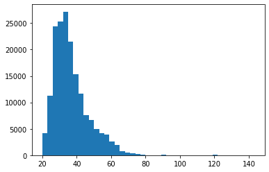

```python
bins = np.arange(df['age'].min(),df['age'].max()+3,3)
plt.hist(data=df,x='age',bins=bins);
```

```python
df[df['age']>70].count()
```

```
duration_sec               852
start_time                 852
end_time                   852
start_station_id           852
start_station_name         852
start_station_latitude     852
start_station_longitude    852
end_station_id             852
end_station_name           852
end_station_latitude       852
end_station_longitude      852
bike_id                    852
user_type                  852
member_birth_year          852
member_gender              852
bike_share_for_all_trip    852
start_weekday              852
start_hour                 852
start_part_of_day          852
age                        852
dtype: int64
```

```python
df = df[df['age']<70]
```

```python
df['duration_min'] = df['duration_sec'] /60
df['duration_hour'] = df['duration_sec'] /3600
```

```python
df[df['duration_min']>40].count()
```

```
duration_sec               3035
start_time                 3035
end_time                   3035
start_station_id           3035
start_station_name         3035
start_station_latitude     3035
start_station_longitude    3035
end_station_id             3035
end_station_name           3035
end_station_latitude       3035
end_station_longitude      3035
bike_id                    3035
user_type                  3035
member_birth_year          3035
member_gender              3035
bike_share_for_all_trip    3035
start_weekday              3035
start_hour                 3035
start_part_of_day          3035
age                        3035
duration_min               3035
duration_hour              3035
dtype: int64
```

```python
df = df[df['duration_min']< 40]
```

```python
df.duration_min.mean()
```

```
9.94894411185821
```

```python
df.duration_min.value_counts()
```

```
4.533333     308
5.083333     282
5.383333     281
6.150000     280
4.566667     275
            ...
37.516667      1
38.700000      1
37.433333      1
39.383333      1
39.816667      1
Name: duration_min, Length: 2329, dtype: int64
```

```python
df.duration_min.min()
```

```
1.0166666666666666
```

```python
df.info()
```

```
<class 'pandas.core.frame.DataFrame'>
Int64Index: 170883 entries, 4 to 183411
Data columns (total 22 columns):
 #   Column                   Non-Null Count   Dtype
---  ------                   --------------   -----
 0   duration_sec             170883 non-null  int64
 1   start_time               170883 non-null  datetime64[ns]
 2   end_time                 170883 non-null  datetime64[ns]
 3   start_station_id         170883 non-null  float64
 4   start_station_name       170883 non-null  object
 5   start_station_latitude   170883 non-null  float64
 6   start_station_longitude  170883 non-null  float64
 7   end_station_id           170883 non-null  float64
 8   end_station_name         170883 non-null  object
 9   end_station_latitude     170883 non-null  float64
 10  end_station_longitude    170883 non-null  float64
 11  bike_id                  170883 non-null  int64
 12  user_type                170883 non-null  object
 13  member_birth_year        170883 non-null  int32
 14  member_gender            170883 non-null  object
 15  bike_share_for_all_trip  170883 non-null  object
 16  start_weekday            170883 non-null  category
 17  start_hour               170883 non-null  int64
 18  start_part_of_day        170883 non-null  category
 19  age                      170883 non-null  int32
 20  duration_min             170883 non-null  float64
 21  duration_hour            170883 non-null  float64
dtypes: category(2), datetime64[ns](2), float64(8), int32(2), int64(3), object(5)
memory usage: 26.4+ MB
```

```python
df.head()
```

|  | duration_sec | start_time | end_time | start_station_id | start_station_name | start_station_latitude | start_station_longitude | end_station_id | end_station_name | end_station_latitude | ... | user_type | member_birth_year | member_gender | bike_share_for_all_trip | start_weekday | start_hour | start_part_of_day | age | duration_min | duration_hour |
| --- | --- | --- | --- | --- | --- | --- | --- | --- | --- | --- | --- | --- | --- | --- | --- | --- | --- | --- | --- | --- | --- |
| 4 | 1585 | 2019-02-28 23:54:18.549 | 2019-03-01 00:20:44.074 | 7.0 | Frank H Ogawa Plaza | 37.804562 | -122.271738 | 222.0 | 10th Ave at E 15th St | 37.792714 | ... | Subscriber | 1974 | Male | Yes | Thursday | 23 | Night | 47 | 26.416667 | 0.440278 |
| 5 | 1793 | 2019-02-28 23:49:58.632 | 2019-03-01 00:19:51.760 | 93.0 | 4th St at Mission Bay Blvd S | 37.770407 | -122.391198 | 323.0 | Broadway at Kearny | 37.798014 | ... | Subscriber | 1959 | Male | No | Thursday | 23 | Night | 62 | 29.883333 | 0.498056 |
| 6 | 1147 | 2019-02-28 23:55:35.104 | 2019-03-01 00:14:42.588 | 300.0 | Palm St at Willow St | 37.317298 | -121.884995 | 312.0 | San Jose Diridon Station | 37.329732 | ... | Subscriber | 1983 | Female | No | Thursday | 23 | Night | 38 | 19.116667 | 0.318611 |
| 7 | 1615 | 2019-02-28 23:41:06.766 | 2019-03-01 00:08:02.756 | 10.0 | Washington St at Kearny St | 37.795393 | -122.404770 | 127.0 | Valencia St at 21st St | 37.756708 | ... | Subscriber | 1989 | Male | No | Thursday | 23 | Night | 32 | 26.916667 | 0.448611 |
| 8 | 1570 | 2019-02-28 23:41:48.790 | 2019-03-01 00:07:59.715 | 10.0 | Washington St at Kearny St | 37.795393 | -122.404770 | 127.0 | Valencia St at 21st St | 37.756708 | ... | Subscriber | 1988 | Other | No | Thursday | 23 | Night | 33 | 26.166667 | 0.436111 |

5 rows × 22 columns

```python
df.to_csv('201902-fordgobike-tripdata__Cleaned.csv')
```

### What is the structure of your dataset?

> this dataset consist of 170883 rows and 22 columns

### What is/are the main feature(s) of interest in your dataset?

> duration, age, start_weekday, user_type

### What features in the dataset do you think will help support your investigation into your feature(s) of interest?

> start_part_of_day

## Univariate Exploration

> In this section, investigate distributions of individual variables. If you see unusual points or outliers, take a deeper look to clean things up and prepare yourself to look at relationships between variables.

> Make sure that, after every plot or related series of plots, that you include a Markdown cell with comments about what you observed, and what you plan on investigating next.

> Make sure that, after every plot or related series of plots, that you include a Markdown cell with comments about what you observed, and what you plan on investigating next.

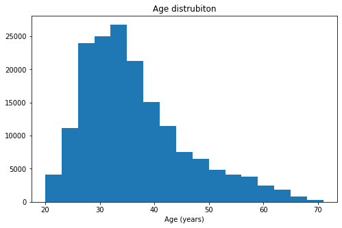

```python
plt.figure(figsize=[8, 5])
bins = np.arange(df['age'].min(),df['age'].max()+3,3)
plt.hist(data=df,x='age',bins=bins);
plt.title('Age distrubiton')
plt.xlabel('Age (years)');
```

> the distrubiton of Biker's ages is right skewed, where most ages fall between 25 - 40

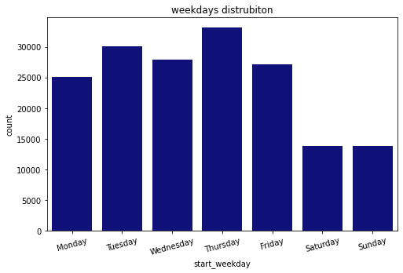

```python
plt.figure(figsize=[8, 5])
sb.countplot(data=df,x='start_weekday',color='darkblue')
plt.title('weekdays distrubiton');
plt.xticks(rotation=15);
```

> as shown in the bar plot most rides are through the work days where the number of rides in the weekends decreases

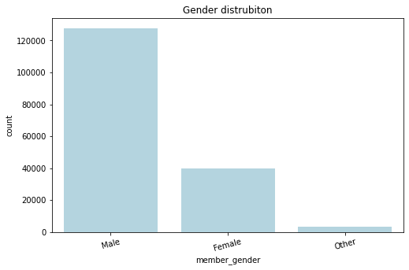

```python
plt.figure(figsize=[8, 5])
sb.countplot(data=df,x='member_gender',color='lightblue')
plt.xticks(rotation=15);
plt.title('Gender distrubiton');
```

> Most bike rides are by Males

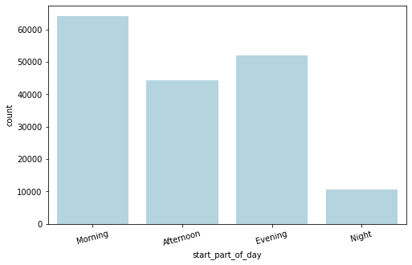

```python
plt.figure(figsize=[8, 5])
sb.countplot(data=df,x='start_part_of_day',color='lightblue')
plt.xticks(rotation=15);
```

> Most rides are in the mornings and then in the evening and after noon, with fewer bike rides in the night, this can be the result of users using bikes commute to work

### Discuss the distribution(s) of your variable(s) of interest. Were there any unusual points? Did you need to perform any transformations?

> I was Interested in the distribution of bike trips across the week. I noticed that most rides are from Monday to friday and on weekends bike rides decreases. I think this is the result of users using bikes to commute to work

### Of the features you investigated, were there any unusual distributions? Did you perform any operations on the data to tidy, adjust, or change the form of the data? If so, why did you do this?

> I wanted to look deeper in the times of bike trips. so I extracted a new column start_part_of_day which indictes whethere the rides were at the morning, afternoon, evening or at night. And It looks that most rides are at the morning and then the evening and afternoon with fewer trips at night

## Bivariate Exploration

> In this section, investigate relationships between pairs of variables in your data. Make sure the variables that you cover here have been introduced in some fashion in the previous section (univariate exploration).

```python
gender_mean = df.groupby('member_gender').mean().reset_index()
```

```python
gender_mean
```

|  | member_gender | duration_sec | start_station_id | start_station_latitude | start_station_longitude | end_station_id | end_station_latitude | end_station_longitude | bike_id | member_birth_year | start_hour | age | duration_min | duration_hour |
| --- | --- | --- | --- | --- | --- | --- | --- | --- | --- | --- | --- | --- | --- | --- |
| 0 | Female | 648.662548 | 137.676511 | 37.780854 | -122.357222 | 135.617318 | 37.781038 | -122.356546 | 4396.508551 | 1985.887215 | 13.206836 | 35.112785 | 10.811042 | 0.180184 |
| 1 | Male | 579.653512 | 138.721967 | 37.767231 | -122.349574 | 135.918927 | 37.767429 | -122.349181 | 4504.341464 | 1984.850982 | 13.523650 | 36.149018 | 9.660892 | 0.161015 |
| 2 | Other | 638.796835 | 150.361151 | 37.798983 | -122.355553 | 148.008921 | 37.798845 | -122.355328 | 4519.636835 | 1983.581871 | 13.688345 | 37.418129 | 10.646614 | 0.177444 |

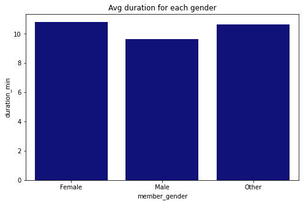

```python
plt.figure(figsize=[8, 5])
sb.barplot(data=gender_mean,x='member_gender',y='duration_min',color='darkblue',);
plt.title('Avg duration for each gender');
```

> In terms of gender, males have slightly lower duration average when compared to other genders
> - Males average duration: 9.6 mins
> - Females average duration: 10.8 mins
> - Others Average Age: 10.6 mins

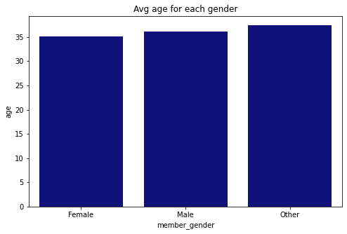

```python
plt.figure(figsize=[8, 5])
sb.barplot(data=gender_mean,x='member_gender',y='age',color='darkblue');
plt.title('Avg age for each gender');
```

> the mean age for all genders is similar across gender
> - Females average Age 35.1 years
> - Males average Age 36.1 years
> - Others average Age 37.4 years

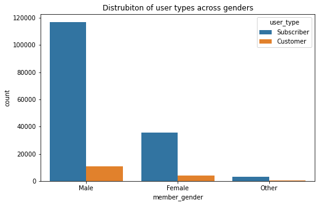

```python
plt.figure(figsize=[8, 5])
sb.countplot(data=df,x='member_gender',hue='user_type');
plt.title('Distrubiton of user types across genders');
```

> Most of the users are subscribers throughout all genders

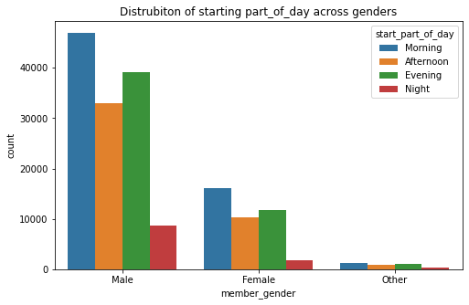

```python
plt.figure(figsize=[8, 5])
sb.countplot(data=df,x='member_gender',hue='start_part_of_day');
plt.title('Distrubiton of starting part_of_day across genders');
```

> the plot above shows that for all genders most trip times are at the Morning, afternoon and evening with very few trips at night

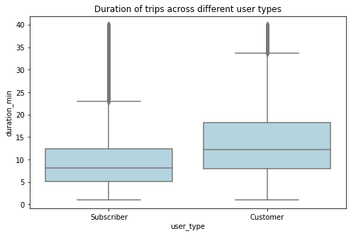

```python
plt.figure(figsize=[8, 5])
sb.boxplot(data=df,x='user_type',y='duration_min',color='lightblue');
plt.title('Duration of trips across different user types');
```

> the box plot shows that the median duration time of customer's trips is higher than the median of the subscribers trips

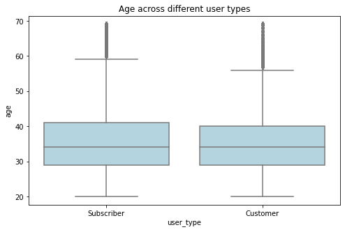

```python
plt.figure(figsize=[8, 5])
sb.boxplot(data=df,x='user_type',y='age',color='lightblue');
plt.title('Age across different user types');
```

> I wanted to see if the user type may have some relation to age, but there is no apparent relation between those two variables.

```python
day_means= df.groupby('start_weekday').mean().reset_index()
```

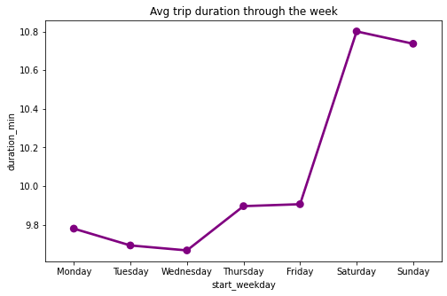

```python
plt.figure(figsize=[8, 5])
sb.pointplot(data=day_means,x='start_weekday',y='duration_min',color='purple');
plt.title('Avg trip duration through the week');
```

> the line plot above shows that duration of rides on weekends is higher than the duration through the workdays, I think this can people are busier on work days and don't want to be late, but on weekends they can take their time

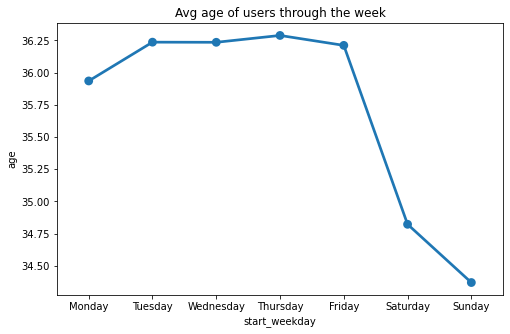

```python
plt.figure(figsize=[8, 5])
sb.pointplot(data=day_means,x='start_weekday',y='age');
plt.title('Avg age of users through the week');
```

> we can see that average age on workdays is higher than the average age on weekends!

```python
daypart_means = df.groupby('start_part_of_day').mean().reset_index()
```

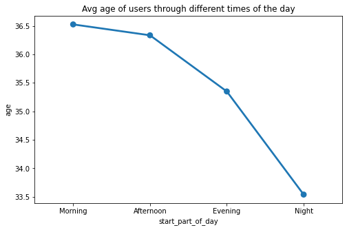

```python
plt.figure(figsize=[8, 5])
sb.pointplot(data=daypart_means,x='start_part_of_day',y='age',)
plt.title('Avg age of users through different times of the day');
```

> we can see that the average age decreases through the day

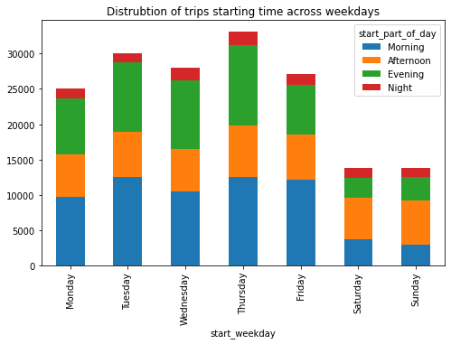

```python
stacked_bar = df.groupby(['start_part_of_day', 'start_weekday']).size().reset_index().pivot(columns='start_part_of_day', index='start_weekday', values=0);
stacked_bar.plot(kind='bar', stacked=True,figsize=(8,5),title='Distrubtion of trips starting time across weekdays');
```

> the above plot show that for all workdays the most common trip times are Morning and Evening but on weekends these two time decreases and trips on the Afternoon increases, again I think this is the result of most people using the bikes to commute to work

### Talk about some of the relationships you observed in this part of the investigation. How did the feature(s) of interest vary with other features in the dataset?

> - I saw that users of type customer their average duration is higher than the duration average of subscribers
> - I noticed that for workdays the average duration time is lower than the average duration on weekends
> - I also noticed that the average age also decreases on weekends when compared to workdays
> - I noticed that that the most common times of day through workdays are morning and evening, but on weekends the most common time is on the afternoon

### Did you observe any interesting relationships between the other features (not the main feature(s) of interest)?

> I tried to see if gender has any relation to other variables but I didn't see any apparent relation

## Multivariate Exploration

> Create plots of three or more variables to investigate your data even further. Make sure that your investigations are justified, and follow from your work in the previous sections.

```python
day_type_means = df.groupby(['start_weekday','user_type']).mean().reset_index()
```

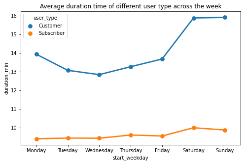

```python
plt.figure(figsize=[8, 5])
sb.pointplot(data=day_type_means,x='start_weekday',y='duration_min',hue='user_type');
plt.title('Average duration time of different user type across the week')
```

> the above pointplot shows that for subscriber the average druation is almost the same throughout the week, but for the user type customer the average duration on workdays fluctuates between 13-14 mins for, but on weekends it increases to around 16 mins

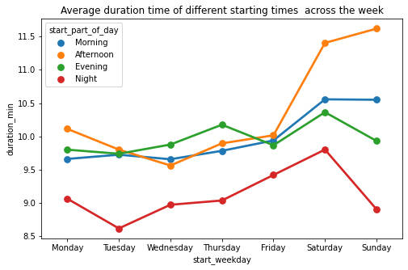

```python
daypart_means = df.groupby(['start_weekday','start_part_of_day']).mean().reset_index()
plt.figure(figsize=[8, 5])
sb.pointplot(data=daypart_means,x='start_weekday',y='duration_min',hue='start_part_of_day');
plt.title('Average duration time of different starting times  across the week')
```

> the above pointplot shows that the duration of rides on the night are always lower than other times throughout the week, it also shows slight increase on duration on afternoon rides on the weekend

### Talk about some of the relationships you observed in this part of the investigation. Were there features that strengthened each other in terms of looking at your feature(s) of interest?

> I noticed the customer user type has higher average duration time on weekends where subscibers are almost consistent throughout the whole week

### Were there any interesting or surprising interactions between features?

> I thought that the morning average trip duration would be lower than other times of the day but it's almost the same as the evening and afternoon

> At the end of your report, make sure that you export the notebook as an html file from the `File > Download as... > HTML` menu. Make sure you keep track of where the exported file goes, so you can put it in the same folder as this notebook for project submission. Also, make sure you remove all of the quote-formatted guide notes like this one before you finish your report!